# Onde se encontra a produção de Bacon no RN?

Fabrício Emiliano Dantas do Rêgo

29/04/2020

# Introdução

Segundo o Censo Agropecuário de 2017 do Instituto Brasileiro de Geografia e Estatística (IBGE), no Rio Grande do Norte existem 63.452 estabelecimentos praticantes da agricultura, desses, 54.742 praticam pecuária, e nesse grupo, 15.735 estabelecimentos fazem criação de suínos. Com base nesses dados, surgiu o interesse de saber qual a maior mesorregião produtora e quais os polos de produção desse animal.

# Coleta de dados

Para isso, foram coletados dados do Censo Agropecuário de 2017 do IBGE sobre o efetivo do rebanho de suínos de cada município e do número de estabelecimentos que criam essa espécie no estado do Rio Grande do Norte. Segundo o instituto: “As informações sobre pessoal ocupado, estoques, **efetivos da pecuária**, lavouras permanentes e silvicultura, entre outros dados estruturais, têm como referência o dia **30 de setembro de 2017** […]”. Portanto, as análises aqui apresentadas referem-se ao dia 30/09/2017, levando-se em consideração que para cada estabelecimento o número de suínos pode diminuir ou aumentar devido aos abates e nascimentos de seus filhotes, não é possível captar a provável flutuação do efetivo do rebanho de suínos neste ano.

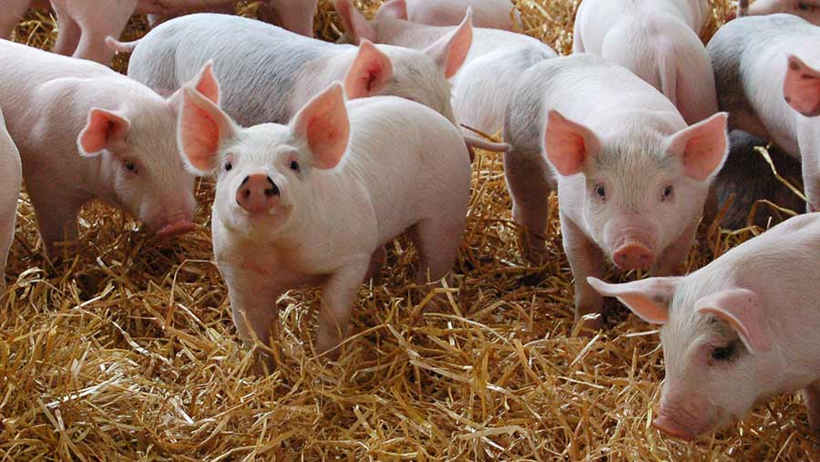

# Estatística descritiva

Para início de análise será realizada a visualização dos dados coletados, começando com o histograma 1. No gráfico, há um comportamento assimétrico à direita onde a massa dos dados se concentra em torno da mediana: 416, além disso verifica-se que algumas barras se distanciam dessa massa que são as cidades com maior produção de suínos. A maior delas produzindo mais do que 4.500 cabeças.

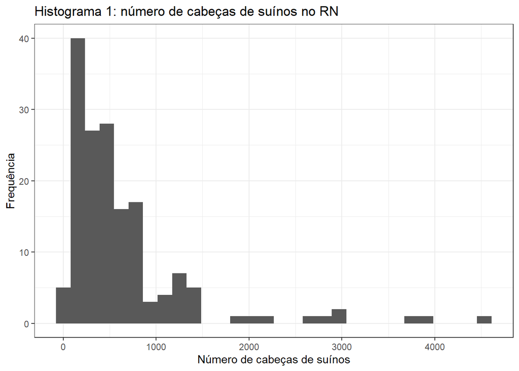

Para visualizar a distribuição da produção de cabeça de suínos de cada mesorregião do estado é apresentado o histograma 2, nele a linha preta representa a mediana, calculada a partir do efetivo do rebanho de todos os municípios. Verifica-se que todas as mesorregiões têm uma massa de dados variando em torno da mediana geral levantando evidências que a produção mantenha um comportamento equivalente para os municípios do estado, salvo excessões presentes nas mesorregiões Central e Oeste Potiguar onde há uma quantidade considerável de municípios que atingem uma produção maior do que 1000 cabeças.

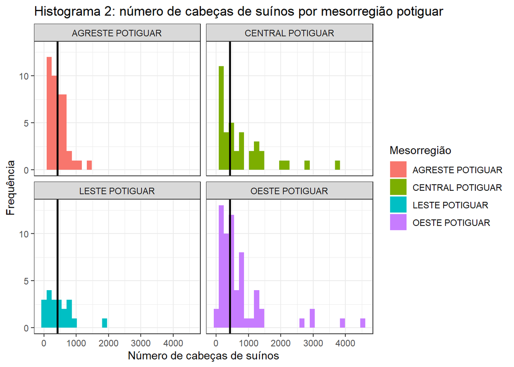

# Compações Múltiplas

Surge então a seguinte dúvida: Será que as quatro mesorregiões apresentam mesmo um comportamento produtivo parecido?

Para descobrir, aplica-se o teste da análise de variância (ANOVA) nos dados, que verifica se  
alguma mesorregião apresenta um comportamento produtivo mais alto (ou mais baixo) do que as outras 3 (três).

## ANOVA

Para esse teste são consideradas duas hipóteses:

$H_0: \mu_1 = \mu_2 = \dots =\mu_4$ (isto é: A média de todas as mesorregiões são iguais.)

Vs

$H_1: \mu_i \neq \mu_j$, para algum $i \neq j$ (A média de alguma mesorregião é diferente da média de outra mesorregião.)

Aplicando o ANOVA e considerando um nível de significância $\alpha = 0,05%$ obtém-se um p-valor de $0,047 < \alpha$. Têm-se fortes evidências para rejeitar a hipótese nula $(H_0)$, ou seja, evidências que a produção de alguma mesorregião seja diferente de outra.

```
##              Df   Sum Sq Mean Sq F value Pr(>F)
## MESORREGIAO   3  4084838 1361613   2.719 0.0465 *
## Residuals   158 79130668  500827
## ---
## Signif. codes:  0 '***' 0.001 '**' 0.01 '*' 0.05 '.' 0.1 ' ' 1
## 5 observations deleted due to missingness
```

Por haver tais evidências, aplica-se as comparações múltiplas nos dados, esse cálculo opera a subtração dos dados de uma mesorregião com os dados de outra e cria intervalos de confiança com base no desvio padrão. O método utilizado foi o teste de diferenças significativamente honestas de tukey. O resultado do teste indica que as evidências anteriores não são verdadeiras informando que a produção das mesorregiões têm comportamento parecido.

Teste de tukey

|  | Diferença | L. Inferior | L. Superior | P-valor |
| --- | --- | --- | --- | --- |
| LESTE POTIGUAR-AGRESTE POTIGUAR | 35.24 | -462.12 | 532.59 | 1.00 |
| OESTE POTIGUAR-AGRESTE POTIGUAR | 318.09 | -46.59 | 682.76 | 0.11 |
| CENTRAL POTIGUAR-AGRESTE POTIGUAR | 361.89 | -50.16 | 773.95 | 0.11 |
| OESTE POTIGUAR-LESTE POTIGUAR | 282.85 | -189.70 | 755.39 | 0.41 |
| CENTRAL POTIGUAR-LESTE POTIGUAR | 326.66 | -183.34 | 836.65 | 0.35 |
| CENTRAL POTIGUAR-OESTE POTIGUAR | 43.81 | -337.93 | 425.55 | 0.99 |

# Melhor mesorregião produtora

Com base nos resultados anteriores, a decisão de qual a maior mesorregião produtora de suínos deve ser tomada com relação a média de produção de cabeças de cada mesorregião, uma vez que essa medida de tendência central leva em conta a influência dos municípios com produção fora do padrão do estado (outliers). Para isso, criou-se a tabela 1 das médias de produção de cada mesorregião, evidenciando que a Central potiguar lidera, com 37 municípios e um total de 3.567 estabelecimentos produtores, apresentando-se como a maior mesorregião produtora da espécie no RN.

Tabela 1: Média da produção em cada mesorregião

| Mesorregião | Média | Número de Municípios | Número de estabelecimentos |
| --- | --- | --- | --- |
| CENTRAL POTIGUAR | 791 | 37 | 3567 |
| OESTE POTIGUAR | 748 | 62 | 7495 |
| LESTE POTIGUAR | 465 | 25 | 985 |
| AGRESTE POTIGUAR | 430 | 43 | 3688 |

Para apresentar os polos com maior produção de suínos no RN, a tabela 2 exibe uma listagem das 10 (dez) cidades com maior produção de suínos do RN em razão decrescente. Nela é destacado o nome do município, assim como o número de cabeças de suínos, número de propriedades, mesorregião e média de produção por propriedade (méd. estabelecimento). Portanto, pode-se concluir que a cidade com maior produção de suínos da mesorregião Oeste Potiguar é Mossoró, sendo ela referência no estado pela sua produção agrícola e pela exportação de melão para o comércio internacional. Sendo seguida por Apodi, também do Oeste Potiguar, que assim como Mossoró é um polo de produção agrícola no estado. A terceira posição é ocupada por Caicó da Central Potiguar. Pode-se inferir claramente que o Oeste Potiguar apresenta as maiores produções do estado do RN, sendo possível levantar a hipótese de que nessa mesorregião o incentivo à agropecuária sobressai os demais estados. Um fenômeno interessante que pode ser observado a partir dos dados apresentados é o de que apesar da produção de suínos estar entre as dez maiores do estado, as cidades de Apodi, São Miguel, Lagoa Nova, possuem uma grande quantidade de estabelecimentos produtores, 579, 875, 802 respectivamente, apresentando um grande potencial produtor nesses municípios. Algumas conjecturas podem ser feitas, sendo a primeira a de que a maioria dos estabelecimentos destas cidades não criam o animal com um manejo técnico ou com uma perspectiva de lucro, diminuindo assim a sua produtividade. Outra suposição plausível é a de que estes estabelecimentos criam outras espécies de animais, como bois, e usam a oportunidade para criar o suíno devido seu fácil manejo.

Tabela 2: top 10 do efetivo do rebanho no estado

| Municípios | Núm. cabeças | Núm. propriedades | Mesorregião | Média por estabelecimento |
| --- | --- | --- | --- | --- |
| MOSSORÓ | 4554 | 378 | OESTE POTIGUAR | 12 |
| APODI | 3978 | 579 | OESTE POTIGUAR | 7 |
| CAICÓ | 3826 | 235 | CENTRAL POTIGUAR | 16 |
| SÃO MIGUEL | 2954 | 875 | OESTE POTIGUAR | 3 |
| JUCURUTU | 2926 | 223 | OESTE POTIGUAR | 13 |
| LAGOA NOVA | 2813 | 802 | CENTRAL POTIGUAR | 4 |
| CARAÚBAS | 2602 | 448 | OESTE POTIGUAR | 6 |
| CRUZETA | 2183 | 84 | CENTRAL POTIGUAR | 26 |
| CERRO CORÁ | 2043 | 418 | CENTRAL POTIGUAR | 5 |
| MACAÍBA | 1810 | 198 | LESTE POTIGUAR | 9 |

# Visualização espacial

Com o intuito de localizar geograficamente os polos produtores de suíno no estado cria-se nas seguintes páginas três mapas. O mapa 1 apresenta o RN subdividido nas mesorregiões geográficas, de acordo com a atual divisão territorial do Brasil.

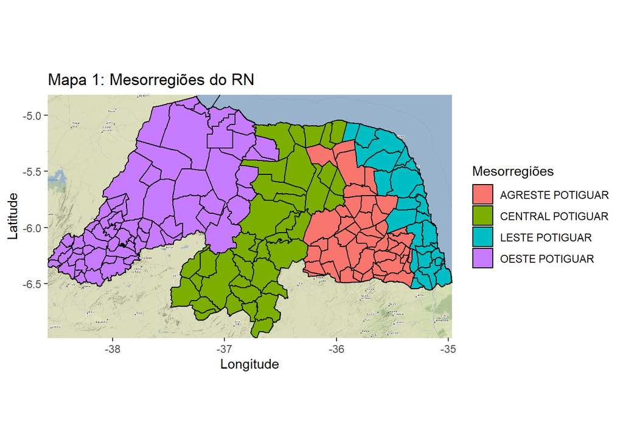

O mapa 2 apresenta a produção de suínos em cada município.

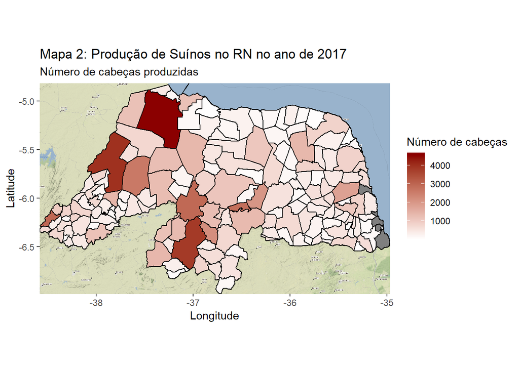

E o mapa 3 apresenta o número de estabelecimentos por município no estado do RN.

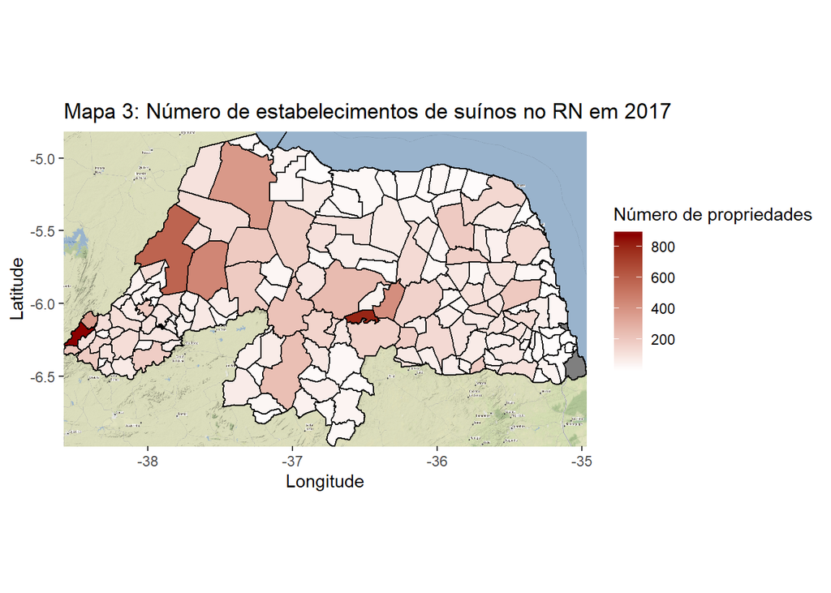

Considerando a legenda, observa-se que há uma tendência de maior produção nos municípios das mesorregiões Oeste e Central Potiguar (Ver mapa 1 e 2), além disso, pode-se observar que a maior quantidade de estabelecimentos criadores também concentram-se no Oeste e Central Potiguar. Pode-se perceber nos mapas que a produção das cidades tendem a ser altas quando essas são vizinhas de cidades que apresentam alta produção e tendem a ser baixas se forem vizinhas de cidades com baixa produção.

# Considerações finais

Esse estudo teve o objetivo de encontrar os polos produtores de suínos, tanto a nível de mesorregião quanto de municípios utilizando os dados do IBGE. Dada as análises é possível dizer que esses objetivos foram alcançados, pois identificou-se qual a mesorregião com maior produção no estado, que foi a Central Potiguar e quais são as cidades com maior produção de suíno no estado.

Os métodos utilizados para alcançar os objetivos foram principalmente a estatística descritiva, a estatística inferencial e espacial. Para identificar qual a mesorregião com maior produção utilizou-se a média de produção de suínos de cada mesorregião, indicando a Central Potiguar como a maior produtora da espécie e utilizando-se da tabela 2 que foi possível ver que Mossoró tem a maior produção, seguido de Apodi, Caicó e assim por diante.

Foi interessante perceber que alguns municípios têm um grande potencial de produção que não estava sendo aproveitado durante o período de coleta do censo, pois existem alguns municípios com uma produção entre as 10 maiores do estado, mas com um número de estabelecimentos produtores imenso. Provavelmente esses estabelecimentos criam suínos  
apenas como complemento pois já devem ter um rebanho de boi ou outros animais, porém se a criação de suíno for trabalhada e incentivada nesses municípios pela prefeitura por exemplo, pode vir a aumentar exponencialmente a produção de suínos.

# Referências

Instituto Brasileiro de Geografia e Estatística, Censo Agropecuário 2017,https://www.ibge.gov.br/estatisticas/economicas/agricultura-e-pecuaria/21814-2017-censo-agropecuario.html?=&t=o-que-e,2017.